# Final Project Step 3: Ensemble Tree Methods for House Price Prediction

Group 6: Cristhian Cruz, Julian McKinley, Luisa Ribeiro, Matheus Lucena

2026-04-13

# 1 Problem Statement

The goal of this project is to predict house sale price using housing characteristics from the King County housing dataset. This is a regression problem, since the response variable is continuous. This problem matters because accurate house price prediction is useful in real estate valuation, pricing strategy, and market analysis. In this final step of the project, we focus on ensemble tree methods from Chapter 8 and compare:

Bagging Random Forest Boosting

A single regression tree is also included as a benchmark, but the main emphasis is on the three required ensemble methods.

# 2 Packages

```r
suppressPackageStartupMessages({
  library(tidyverse)
  library(caret)
  library(rpart)
  library(rpart.plot)
  library(gbm)
  library(knitr)
  library(ranger)
  library(parallel)
  library(pdp)
})

N_CORES <- max(1, detectCores() - 1)   # leave 1 core free
```

```r
N_CORES
```

```
## [1] 7
```

# 3 Helper Functions

```r
set.seed(5703)

price_metrics <- function(pred_log, actual_price) {
  pred_price <- exp(as.numeric(pred_log))
  mse <- mean((actual_price - pred_price)^2)
  rmse <- sqrt(mse)
  mae <- mean(abs(actual_price - pred_price))
  r2 <- 1 - sum((actual_price - pred_price)^2) /
    sum((actual_price - mean(actual_price))^2)

  tibble(
    RMSE = rmse,
    MAE = mae,
    MSE = mse,
    R2 = r2
  )
}

print_price_metrics <- function(model_name, pred_log, actual_price) {
  out <- price_metrics(pred_log, actual_price)
  cat(model_name, "\n")
  cat("RMSE:", round(out$RMSE, 3), "\n")
  cat("MAE :", round(out$MAE, 3), "\n")
  cat("MSE :", round(out$MSE, 3), "\n")
  cat("R^2 :", round(out$R2, 6), "\n\n")
  invisible(out)
}

extract_oob_mse <- function(rf_fit) {
  rf_fit$prediction.error
}

extract_oob_rsq <- function(rf_fit) {
  rf_fit$r.squared
}
```

# 4 Data Description and Loading

The dataset used is kc_house_data.csv. The response variable is price. Because house prices are strongly right-skewed, we model log(price) and then transform predictions back to the original price scale for evaluation.

```r
df_raw <- read.csv("kc_house_data.csv")
str(df_raw)
summary(df_raw$price)
```

```
## 'data.frame':    21613 obs. of  21 variables:
##  $ id           : num  7.13e+09 6.41e+09 5.63e+09 2.49e+09 1.95e+09 ...
##  $ date         : chr  "20141013T000000" "20141209T000000" "20150225T000000" "20141209T000000" ...
##  $ price        : num  221900 538000 180000 604000 510000 ...
##  $ bedrooms     : int  3 3 2 4 3 4 3 3 3 3 ...
##  $ bathrooms    : num  1 2.25 1 3 2 4.5 2.25 1.5 1 2.5 ...
##  $ sqft_living  : int  1180 2570 770 1960 1680 5420 1715 1060 1780 1890 ...
##  $ sqft_lot     : int  5650 7242 10000 5000 8080 101930 6819 9711 7470 6560 ...
##  $ floors       : num  1 2 1 1 1 1 2 1 1 2 ...
##  $ waterfront   : int  0 0 0 0 0 0 0 0 0 0 ...
##  $ view         : int  0 0 0 0 0 0 0 0 0 0 ...
##  $ condition    : int  3 3 3 5 3 3 3 3 3 3 ...
##  $ grade        : int  7 7 6 7 8 11 7 7 7 7 ...
##  $ sqft_above   : int  1180 2170 770 1050 1680 3890 1715 1060 1050 1890 ...
##  $ sqft_basement: int  0 400 0 910 0 1530 0 0 730 0 ...
##  $ yr_built     : int  1955 1951 1933 1965 1987 2001 1995 1963 1960 2003 ...
##  $ yr_renovated : int  0 1991 0 0 0 0 0 0 0 0 ...
##  $ zipcode      : int  98178 98125 98028 98136 98074 98053 98003 98198 98146 98038 ...
##  $ lat          : num  47.5 47.7 47.7 47.5 47.6 ...
##  $ long         : num  -122 -122 -122 -122 -122 ...
##  $ sqft_living15: int  1340 1690 2720 1360 1800 4760 2238 1650 1780 2390 ...
##  $ sqft_lot15   : int  5650 7639 8062 5000 7503 101930 6819 9711 8113 7570 ...
##    Min. 1st Qu.  Median    Mean 3rd Qu.    Max.
##   75000  321950  450000  540088  645000 7700000
```

# 5 Data Cleaning and Preprocessing

We convert appropriate variables to factors, create a log-transformed response, and remove identifier-type fields that are not useful as predictors.

```r
df <- df_raw %>%
  mutate(
    # Convert to proper datetime
    date = as.POSIXct(date, format = "%Y%m%dT%H%M%S"),

    # Extract useful features
    sale_year  = as.numeric(format(date, "%Y")),
    sale_month = as.numeric(format(date, "%m")),
    sale_day   = as.numeric(format(date, "%d")),
    sale_dow   = as.numeric(format(date, "%u")),  # day of week (1–7)

    # Optional: continuous time feature
    sale_time_numeric = as.numeric(date),

    # Existing transformations
    zipcode = factor(zipcode),
    waterfront = factor(waterfront),
    view = factor(view),
    condition = factor(condition),
    grade = factor(grade),
    log_price = log(price)
  )

# Drop identifier / raw date fields if present
drop_cols <- intersect(names(df), c("id", "date"))
df_model <- df %>% select(-all_of(drop_cols))

glimpse(df_model)
```

```
## Rows: 21,613
## Columns: 25
## $ price             <dbl> 221900, 538000, 180000, 604000, 510000, 1225000, 257…
## $ bedrooms          <int> 3, 3, 2, 4, 3, 4, 3, 3, 3, 3, 3, 2, 3, 3, 5, 4, 3, 4…
## $ bathrooms         <dbl> 1.00, 2.25, 1.00, 3.00, 2.00, 4.50, 2.25, 1.50, 1.00…
## $ sqft_living       <int> 1180, 2570, 770, 1960, 1680, 5420, 1715, 1060, 1780,…
## $ sqft_lot          <int> 5650, 7242, 10000, 5000, 8080, 101930, 6819, 9711, 7…
## $ floors            <dbl> 1.0, 2.0, 1.0, 1.0, 1.0, 1.0, 2.0, 1.0, 1.0, 2.0, 1.…
## $ waterfront        <fct> 0, 0, 0, 0, 0, 0, 0, 0, 0, 0, 0, 0, 0, 0, 0, 0, 0, 0…
## $ view              <fct> 0, 0, 0, 0, 0, 0, 0, 0, 0, 0, 0, 0, 0, 0, 0, 3, 0, 0…
## $ condition         <fct> 3, 3, 3, 5, 3, 3, 3, 3, 3, 3, 3, 4, 4, 4, 3, 3, 3, 4…
## $ grade             <fct> 7, 7, 6, 7, 8, 11, 7, 7, 7, 7, 8, 7, 7, 7, 7, 9, 7, …
## $ sqft_above        <int> 1180, 2170, 770, 1050, 1680, 3890, 1715, 1060, 1050,…
## $ sqft_basement     <int> 0, 400, 0, 910, 0, 1530, 0, 0, 730, 0, 1700, 300, 0,…
## $ yr_built          <int> 1955, 1951, 1933, 1965, 1987, 2001, 1995, 1963, 1960…
## $ yr_renovated      <int> 0, 1991, 0, 0, 0, 0, 0, 0, 0, 0, 0, 0, 0, 0, 0, 0, 0…
## $ zipcode           <fct> 98178, 98125, 98028, 98136, 98074, 98053, 98003, 981…
## $ lat               <dbl> 47.5112, 47.7210, 47.7379, 47.5208, 47.6168, 47.6561…
## $ long              <dbl> -122.257, -122.319, -122.233, -122.393, -122.045, -1…
## $ sqft_living15     <int> 1340, 1690, 2720, 1360, 1800, 4760, 2238, 1650, 1780…
## $ sqft_lot15        <int> 5650, 7639, 8062, 5000, 7503, 101930, 6819, 9711, 81…
## $ sale_year         <dbl> 2014, 2014, 2015, 2014, 2015, 2014, 2014, 2015, 2015…
## $ sale_month        <dbl> 10, 12, 2, 12, 2, 5, 6, 1, 4, 3, 4, 5, 5, 10, 3, 1, …
## $ sale_day          <dbl> 13, 9, 25, 9, 18, 12, 27, 15, 15, 12, 3, 27, 28, 7, …
## $ sale_dow          <dbl> 1, 2, 3, 2, 3, 1, 5, 4, 3, 4, 5, 2, 3, 2, 4, 6, 4, 4…
## $ sale_time_numeric <dbl> 1413172800, 1418101200, 1424840400, 1418101200, 1424…
## $ log_price         <dbl> 12.30998, 13.19561, 12.10071, 13.31133, 13.14217, 14…
```

# 6 Train/Test Split

We use an 80/20 train/test split. All models are trained on the same training set and evaluated on the same test set for a fair comparison.

```r
set.seed(5703)
idx <- createDataPartition(df_model$log_price, p = 0.80, list = FALSE)

train_df <- df_model[idx, , drop = FALSE]
test_df  <- df_model[-idx, , drop = FALSE]

cat("Training rows:", nrow(train_df), "\n")
cat("Test rows:", nrow(test_df), "\n")

# Encode zipcode using training data only
zip_medians <- train_df %>%
  group_by(zipcode) %>%
  summarize(zipcode_log_median = median(log_price), .groups = "drop")

train_df <- train_df %>%
  left_join(zip_medians, by = "zipcode")

test_df <- test_df %>%
  left_join(zip_medians, by = "zipcode")

overall_train_log_median <- median(train_df$log_price)

test_df <- test_df %>%
  mutate(
    zipcode_log_median = if_else(
      is.na(zipcode_log_median),
      overall_train_log_median,
      zipcode_log_median
    )
  )

# Remove original zipcode after encoding
train_df <- train_df %>% select(-zipcode)
test_df  <- test_df %>% select(-zipcode)

glimpse(train_df)
glimpse(test_df)
```

```
## Training rows: 17292
## Test rows: 4321
## Rows: 17,292
## Columns: 25
## $ price              <dbl> 538000, 180000, 510000, 291850, 323000, 662500, 468…
## $ bedrooms           <int> 3, 2, 3, 3, 3, 3, 2, 3, 3, 5, 4, 3, 4, 2, 3, 3, 3, …
## $ bathrooms          <dbl> 2.25, 1.00, 2.00, 1.50, 2.50, 2.50, 1.00, 1.00, 1.7…
## $ sqft_living        <int> 2570, 770, 1680, 1060, 1890, 3560, 1160, 1430, 1370…
## $ sqft_lot           <int> 7242, 10000, 8080, 9711, 6560, 9796, 6000, 19901, 9…
## $ floors             <dbl> 2.0, 1.0, 1.0, 1.0, 2.0, 1.0, 1.0, 1.5, 1.0, 1.5, 2…
## $ waterfront         <fct> 0, 0, 0, 0, 0, 0, 0, 0, 0, 0, 0, 0, 0, 0, 0, 0, 0, …
## $ view               <fct> 0, 0, 0, 0, 0, 0, 0, 0, 0, 0, 3, 0, 0, 0, 0, 0, 0, …
## $ condition          <fct> 3, 3, 3, 3, 3, 3, 4, 4, 4, 3, 3, 3, 4, 4, 4, 4, 5, …
## $ grade              <fct> 7, 6, 8, 7, 7, 8, 7, 7, 7, 7, 9, 7, 7, 7, 7, 8, 6, …
## $ sqft_above         <int> 2170, 770, 1680, 1060, 1890, 1860, 860, 1430, 1370,…
```

[output cut: 41 more lines]

# 7 Model Matrices for Bagging and Random Forest

For ranger(), we create predictor matrices and response vectors. We exclude both price and log_price from predictors, and use log_price as the response.

```r
x_train <- train_df %>% select(-price, -log_price)
x_test  <- test_df %>% select(-price, -log_price)

y_train <- train_df$log_price
y_test  <- test_df$log_price

p <- ncol(x_train)

cat("Number of predictors used:", p, "\n")
```

```
## Number of predictors used: 23
```

# 8 Baseline Model: Single Regression Tree

A single regression tree is included only as a benchmark. It is not one of the required ensemble methods, but it helps show whether the ensembles improve predictive performance.

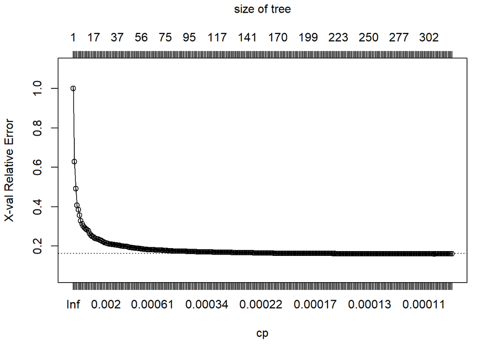

```r
tree_model <- rpart(
  log_price ~ . - price,
  data = train_df,
  method = "anova",
  control = rpart.control(cp = 0.0001)
)

printcp(tree_model)
plotcp(tree_model)
```

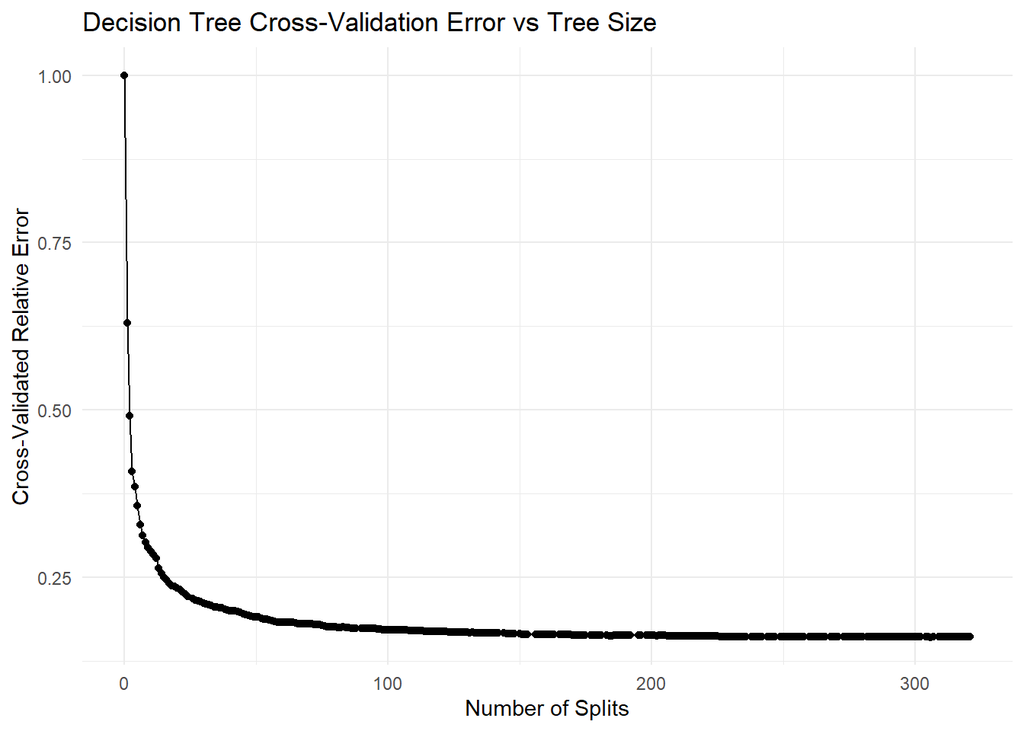

```r
tree_cp_df <- as.data.frame(tree_model$cptable)

ggplot(tree_cp_df, aes(x = nsplit, y = xerror)) +
  geom_line() +
  geom_point() +
  labs(
    title = "Decision Tree Cross-Validation Error vs Tree Size",
    x = "Number of Splits",
    y = "Cross-Validated Relative Error"
  ) +
  theme_minimal()
```

[figure not shown]

```r
best_cp <- tree_model$cptable[
  which.min(tree_model$cptable[, "xerror"]),
  "CP"
]

cat("Best cp selected from cross-validation table:", best_cp, "\n")

pruned_tree <- prune(tree_model, cp = best_cp)

rpart.plot(pruned_tree, main = "Pruned Regression Tree")
```

```r
pred_log_tree <- predict(pruned_tree, newdata = test_df)

tree_test_metrics <- print_price_metrics(
  "Decision Tree Test Metrics:",
  pred_log_tree,
  test_df$price
)
```

```
##
## Regression tree:
## rpart(formula = log_price ~ . - price, data = train_df, method = "anova",
##     control = rpart.control(cp = 1e-04))
##
## Variables actually used in tree construction:
##  [1] bathrooms          condition          grade              lat
##  [5] long               sale_day           sale_time_numeric  sqft_above
##  [9] sqft_basement      sqft_living        sqft_living15      sqft_lot
## [13] sqft_lot15         view               waterfront         yr_built
## [17] zipcode_log_median
##
## Root node error: 4844.5/17292 = 0.28016
##
## n= 17292
```

[output cut: 309 more lines]

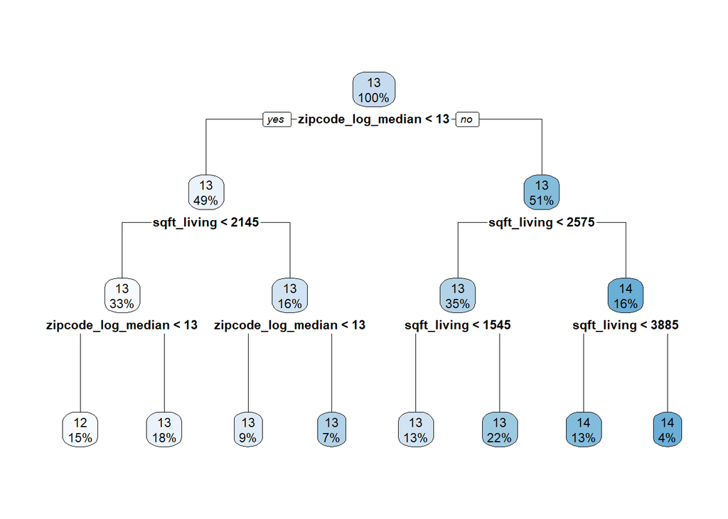

```r
smaller_tree <- prune(pruned_tree, cp = 0.01)
rpart.plot(smaller_tree)
```

# 9 Bagging

Bagging fits many trees using bootstrap samples and averages the predictions. For bagging, the number of variables tried at each split is set equal to the total number of predictors, so mtry = p.

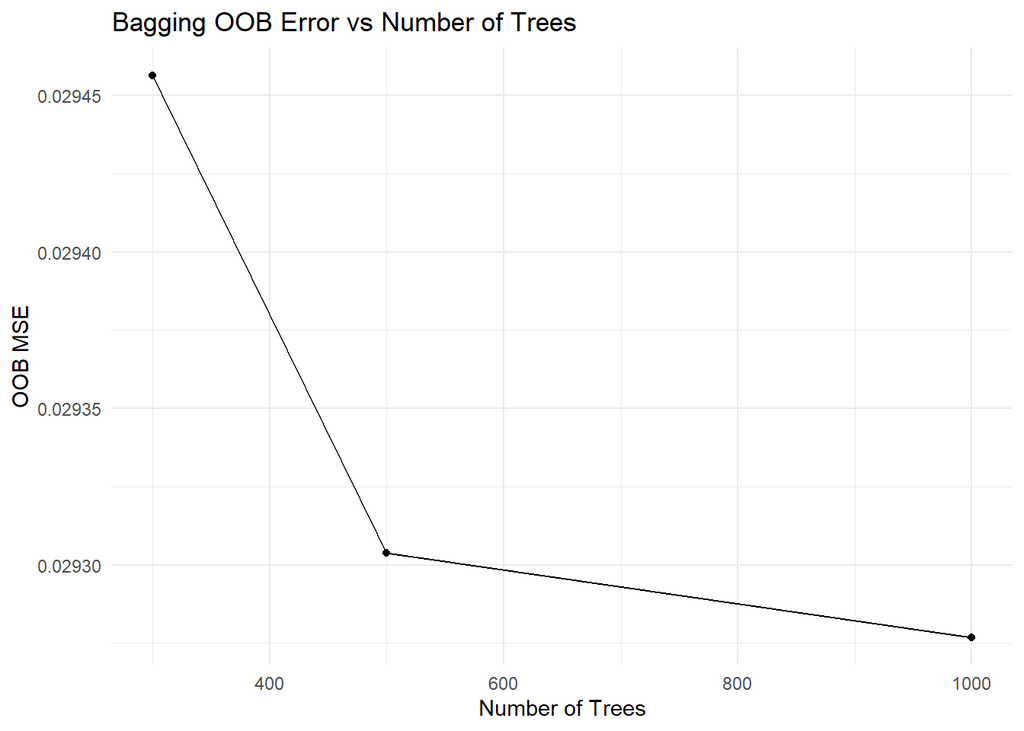

```r
set.seed(5703)

bag_ntree_grid <- c(300, 500, 1000)

bagging_tuning_results <- map_dfr(bag_ntree_grid, function(nt) {
  fit <- ranger(
    x = x_train,
    y = y_train,
    mtry = p,
    num.trees = nt,
    importance = "impurity"
  )

  tibble(
    ntree = nt,
    mtry = p,
    OOB_MSE = extract_oob_mse(fit),
    OOB_R2 = extract_oob_rsq(fit)
  )
})

ggplot(bagging_tuning_results, aes(x = ntree, y = OOB_MSE)) +
  geom_line() +
  geom_point() +
  labs(
    title = "Bagging OOB Error vs Number of Trees",
    x = "Number of Trees",
    y = "OOB MSE"
  ) +
  theme_minimal()
```

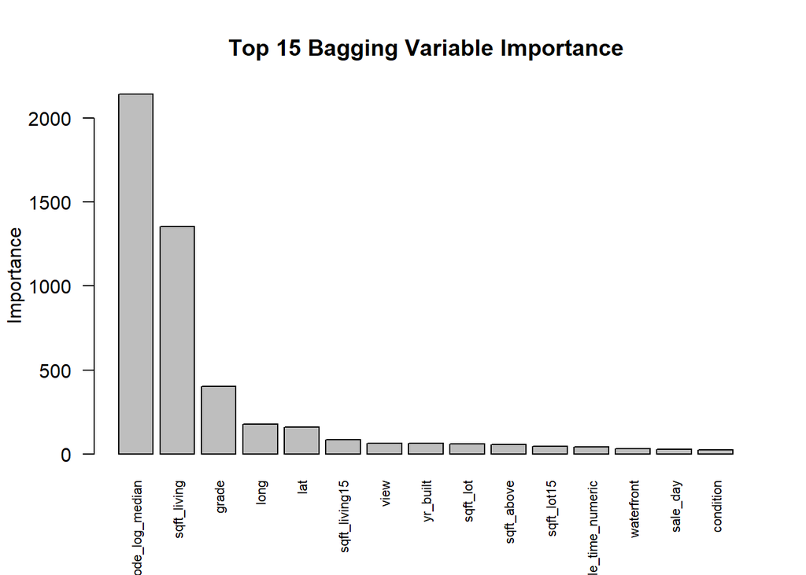

```r
kable(
  bagging_tuning_results,
  digits = 5,
  caption = "Bagging tuning results based on out-of-bag error"
)

best_bag_ntree <- bagging_tuning_results %>%
  arrange(OOB_MSE) %>%
  slice(1) %>%
  pull(ntree)

cat("Best ntree for bagging:", best_bag_ntree, "\n")

bagging_model <- ranger(
  x = x_train,
  y = y_train,
  mtry = p,
  num.trees = best_bag_ntree,
  importance = "impurity"
)

bagging_model
bag_importance_values <- sort(importance(bagging_model), decreasing = TRUE)
barplot(
  head(bag_importance_values, 15),
  las = 2,
  cex.names = 0.7,
  main = "Top 15 Bagging Variable Importance",
  ylab = "Importance"
)
```

```r
pred_log_bag <- predict(bagging_model, data = x_test)$predictions

bagging_test_metrics <- print_price_metrics(
  "Bagging Test Metrics:",
  pred_log_bag,
  test_df$price
)
```

Bagging tuning results based on out-of-bag error

| ntree | mtry | OOB_MSE | OOB_R2 |
| --- | --- | --- | --- |
| 300 | 23 | 0.02946 | 0.89486 |
| 500 | 23 | 0.02930 | 0.89541 |
| 1000 | 23 | 0.02928 | 0.89550 |

```
## Best ntree for bagging: 1000
## Ranger result
##
## Call:
##  ranger(x = x_train, y = y_train, mtry = p, num.trees = best_bag_ntree,      importance = "impurity")
##
## Type:                             Regression
## Number of trees:                  1000
## Sample size:                      17292
## Number of independent variables:  23
## Mtry:                             23
## Target node size:                 5
## Variable importance mode:         impurity
## Splitrule:                        variance
## OOB prediction error (MSE):       0.02924791
## R squared (OOB):                  0.8956079
## Bagging Test Metrics:
## RMSE: 122107.1
## MAE : 66690.59
## MSE : 14910152294
## R^2 : 0.864599
```

# 10 Random Forest

Random forest improves on bagging by considering a random subset of predictors at each split. Instead of a very small tuning grid, we tune both mtry and ntree using out-of-bag performance and then fit the final model with the best settings.

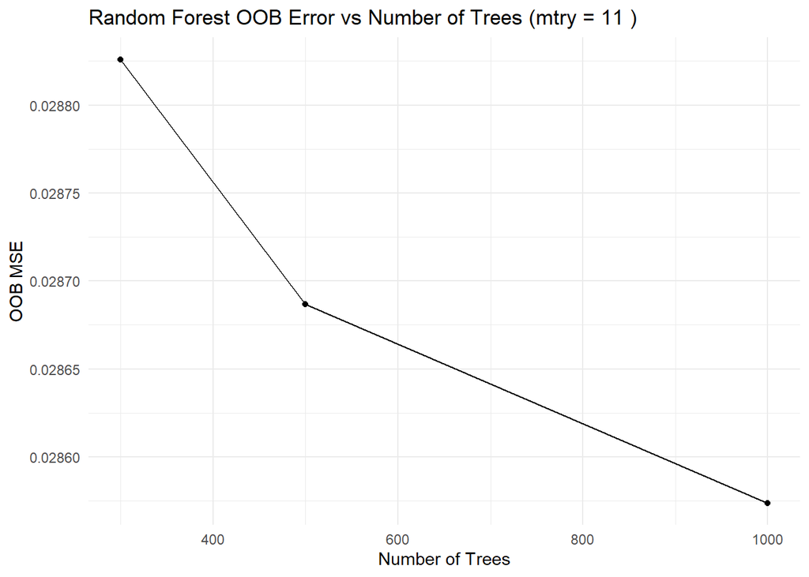

```r
set.seed(5703)

rf_mtry_grid <- unique(c(
  2,
  max(2, floor(sqrt(p))),
  max(2, floor(p / 4)),
  max(2, floor(p / 3)),
  max(2, floor(p / 2)),
  p
))

rf_ntree_grid <- c(300, 500, 1000)

rf_grid <- expand.grid(
  mtry = rf_mtry_grid,
  ntree = rf_ntree_grid
) %>%
  as_tibble() %>%
  arrange(mtry, ntree)

rf_tuning_results <- pmap_dfr(rf_grid, function(mtry, ntree) {
  fit <- ranger(
    x = x_train,
    y = y_train,
    mtry = mtry,
    num.trees = ntree,
    importance = "impurity"
  )

  tibble(
    mtry = mtry,
    ntree = ntree,
    OOB_MSE = extract_oob_mse(fit),
    OOB_R2 = extract_oob_rsq(fit)
  )
})

rf_tuning_results %>%
  arrange(OOB_MSE) %>%
  kable(digits = 5, caption = "Random Forest Tuning Results")

best_rf_mtry_plot <- rf_tuning_results %>%
  arrange(OOB_MSE) %>%
  slice(1) %>%
  pull(mtry)

rf_ntree_plot_df <- rf_tuning_results %>%
  filter(mtry == best_rf_mtry_plot)

ggplot(rf_ntree_plot_df, aes(x = ntree, y = OOB_MSE)) +
  geom_line() +
  geom_point() +
  labs(
    title = paste("Random Forest OOB Error vs Number of Trees (mtry =", best_rf_mtry_plot, ")"),
    x = "Number of Trees",
    y = "OOB MSE"
  ) +
  theme_minimal()
```

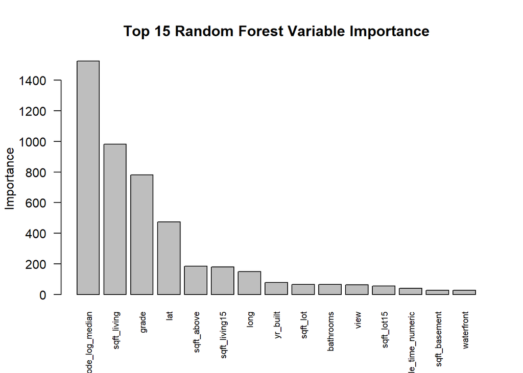

```r
best_rf_params <- rf_tuning_results %>%
  arrange(OOB_MSE) %>%
  slice(1)

best_mtry <- best_rf_params$mtry
best_rf_ntree <- best_rf_params$ntree

cat("Best mtry for random forest:", best_mtry, "\n")
cat("Best ntree for random forest:", best_rf_ntree, "\n")

set.seed(5703)
rf_model <- ranger(
  x = x_train,
  y = y_train,
  mtry = best_mtry,
  num.trees = best_rf_ntree,
  importance = "impurity"
)

rf_model
rf_importance_values <- sort(importance(rf_model), decreasing = TRUE)
barplot(
  head(rf_importance_values, 15),
  las = 2,
  cex.names = 0.7,
  main = "Top 15 Random Forest Variable Importance",
  ylab = "Importance"
)
```

```r
pred_log_rf <- predict(rf_model, data = x_test)$predictions

rf_test_metrics <- print_price_metrics(
  "Random Forest Test Metrics:",
  pred_log_rf,
  test_df$price
)
```

Random Forest Tuning Results

| mtry | ntree | OOB_MSE | OOB_R2 |
| --- | --- | --- | --- |
| 11 | 1000 | 0.02857 | 0.89801 |
| 7 | 1000 | 0.02863 | 0.89782 |
| 11 | 500 | 0.02869 | 0.89761 |
| 7 | 500 | 0.02877 | 0.89731 |
| 7 | 300 | 0.02882 | 0.89713 |
| 11 | 300 | 0.02883 | 0.89711 |
| 5 | 1000 | 0.02894 | 0.89671 |
| 5 | 500 | 0.02899 | 0.89654 |
| 5 | 300 | 0.02916 | 0.89592 |
| 4 | 1000 | 0.02923 | 0.89567 |
| 23 | 1000 | 0.02926 | 0.89557 |
| 23 | 500 | 0.02935 | 0.89524 |
| 4 | 500 | 0.02938 | 0.89514 |
| 23 | 300 | 0.02948 | 0.89477 |
| 4 | 300 | 0.02961 | 0.89431 |
| 2 | 1000 | 0.03249 | 0.88405 |
| 2 | 300 | 0.03266 | 0.88343 |
| 2 | 500 | 0.03269 | 0.88334 |

```
## Best mtry for random forest: 11
## Best ntree for random forest: 1000
## Ranger result
##
## Call:
##  ranger(x = x_train, y = y_train, mtry = best_mtry, num.trees = best_rf_ntree,      importance = "impurity")
##
## Type:                             Regression
## Number of trees:                  1000
## Sample size:                      17292
## Number of independent variables:  23
## Mtry:                             11
## Target node size:                 5
## Variable importance mode:         impurity
## Splitrule:                        variance
## OOB prediction error (MSE):       0.02855002
## R squared (OOB):                  0.8980988
## Random Forest Test Metrics:
## RMSE: 120440.4
## MAE : 65748.2
## MSE : 14505886496
## R^2 : 0.868271
```

# 11 Boosting

Boosting builds trees sequentially, with each new tree focusing on errors made by the previous ones. Here we tune interaction depth, shrinkage, and minimum node size, then choose the best number of trees by cross-validation for each combination.

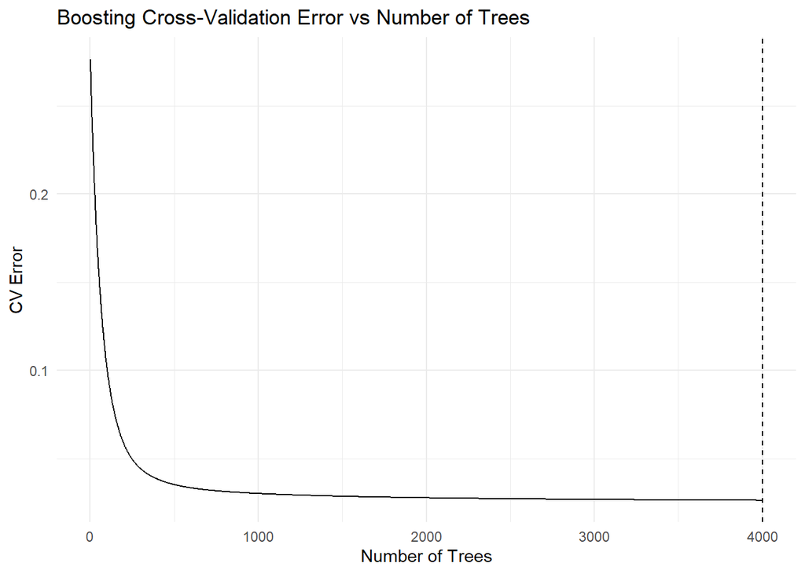

```r
set.seed(5703)

boost_grid <- expand.grid(
  interaction.depth = c(1, 3, 5),
  shrinkage = c(0.005, 0.01),
  n.minobsinnode = c(5, 10),
  KEEP.OUT.ATTRS = FALSE
) %>%
  as_tibble()

boost_tuning_results <- pmap_dfr(boost_grid, function(interaction.depth, shrinkage, n.minobsinnode) {
  fit <- gbm(
    log_price ~ . - price,
    data = train_df,
    distribution = "gaussian",
    n.trees = 4000,
    interaction.depth = interaction.depth,
    shrinkage = shrinkage,
    n.minobsinnode = n.minobsinnode,
    cv.folds = 5,
    n.cores = N_CORES,
    bag.fraction = 0.5,
    verbose = FALSE
  )

  best_iter <- gbm.perf(fit, method = "cv", plot.it = FALSE)
  best_cv_error <- fit$cv.error[best_iter]

  tibble(
    interaction.depth = interaction.depth,
    shrinkage = shrinkage,
    n.minobsinnode = n.minobsinnode,
    best_iter = best_iter,
    CV_Error = best_cv_error
  )
})

boost_tuning_results %>%
  arrange(CV_Error) %>%
  kable(digits = 5, caption = "Boosting tuning results based on 5-fold CV")

best_boost_params <- boost_tuning_results %>%
  arrange(CV_Error) %>%
  slice(1)

cat("Best boosting depth:", best_boost_params$interaction.depth, "\n")
cat("Best boosting shrinkage:", best_boost_params$shrinkage, "\n")
cat("Best boosting n.minobsinnode:", best_boost_params$n.minobsinnode, "\n")
cat("Best boosting number of trees:", best_boost_params$best_iter, "\n")

boost_model <- gbm(
  log_price ~ . - price,
  data = train_df,
  distribution = "gaussian",
  n.trees = best_boost_params$best_iter,
  interaction.depth = best_boost_params$interaction.depth,
  shrinkage = best_boost_params$shrinkage,
  n.minobsinnode = best_boost_params$n.minobsinnode,
  cv.folds = 5,
  n.cores = N_CORES,
  bag.fraction = 0.5,
  verbose = FALSE
)

boost_cv_df <- data.frame(
  Trees = seq_along(boost_model$cv.error),
  CV_Error = boost_model$cv.error
)

best_iter_final <- gbm.perf(boost_model, method = "cv", plot.it = FALSE)

ggplot(boost_cv_df, aes(x = Trees, y = CV_Error)) +
  geom_line() +
  geom_vline(xintercept = best_iter_final, linetype = "dashed") +
  labs(
    title = "Boosting Cross-Validation Error vs Number of Trees",
    x = "Number of Trees",
    y = "CV Error"
  ) +
  theme_minimal()
```

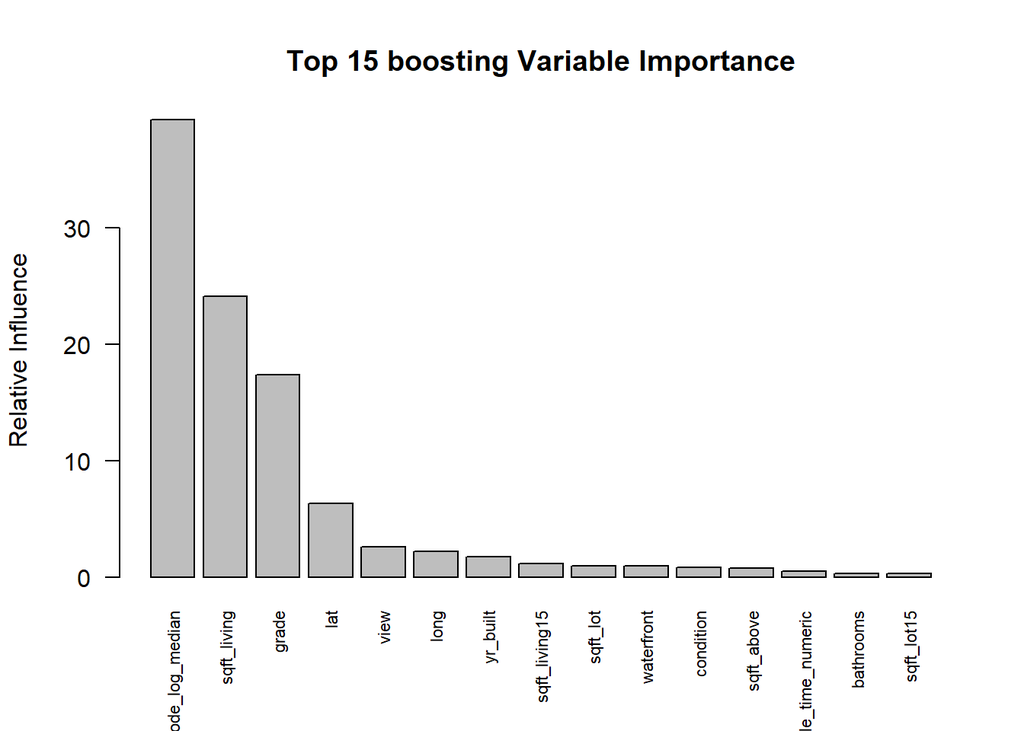

```r
boost_importance_values <- summary(boost_model, plotit = FALSE)
gbm_importance_values <- boost_importance_values$rel.inf
names(gbm_importance_values) <- boost_importance_values$var
barplot(
  head(gbm_importance_values, 15),
  las = 2,
  cex.names = 0.7,
  main = "Top 15 boosting Variable Importance",
  ylab = "Relative Influence"
)
```

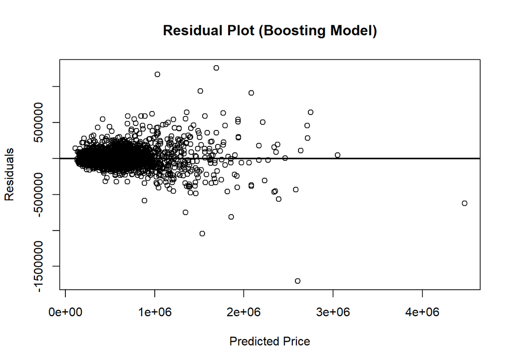

```r
pred_log_boost <- predict(
  boost_model,
  newdata = test_df,
  n.trees = best_boost_params$best_iter
)

boost_test_metrics <- print_price_metrics(
  "Boosting Test Metrics:",
  pred_log_boost,
  test_df$price
)

# Residual Analysis for Boosting
actual_price <- test_df$price
pred_price <- exp(pred_log_boost)
residuals <- actual_price - pred_price

# Residual Plot
plot(pred_price, residuals,
     xlab = "Predicted Price",
     ylab = "Residuals",
     main = "Residual Plot (Boosting Model)")
abline(h = 0, lwd = 2)
```

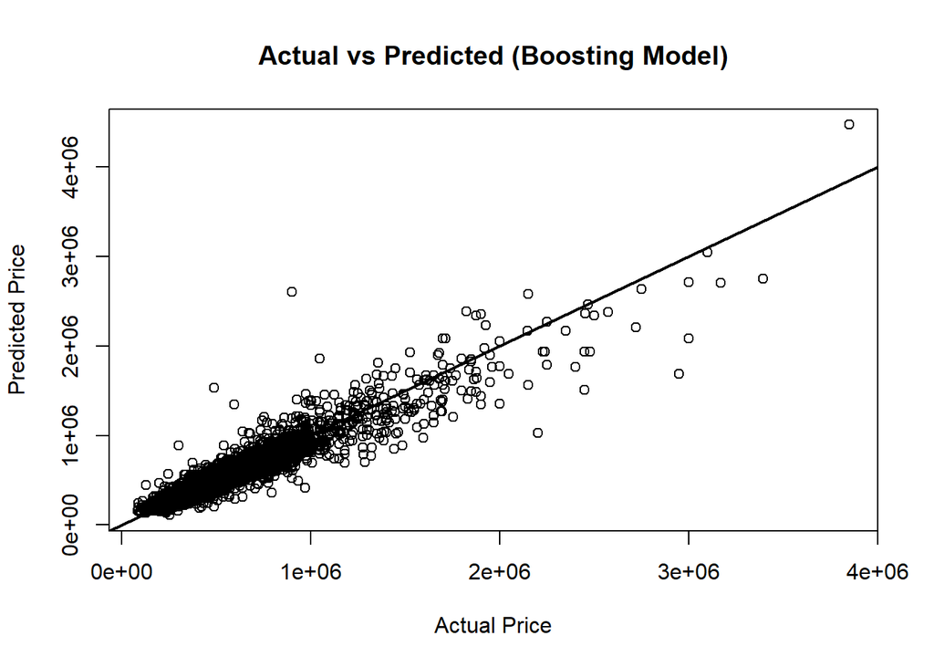

```r
# Actual vs Predicted
plot(actual_price, pred_price,
     xlab = "Actual Price",
     ylab = "Predicted Price",
     main = "Actual vs Predicted (Boosting Model)")
abline(0, 1, lwd = 2)
```

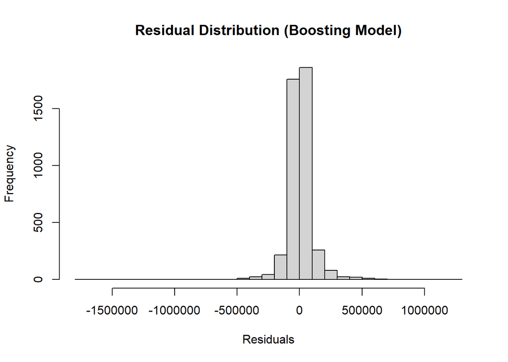

Boosting tuning results based on 5-fold CV

| interaction.depth | shrinkage | n.minobsinnode | best_iter | CV_Error |
| --- | --- | --- | --- | --- |
| 5 | 0.010 | 5 | 4000 | 0.02630 |
| 5 | 0.010 | 10 | 4000 | 0.02636 |
| 3 | 0.010 | 10 | 4000 | 0.02756 |
| 5 | 0.005 | 10 | 4000 | 0.02764 |
| 3 | 0.010 | 5 | 3998 | 0.02768 |
| 5 | 0.005 | 5 | 4000 | 0.02771 |
| 3 | 0.005 | 10 | 4000 | 0.02951 |
| 3 | 0.005 | 5 | 4000 | 0.02954 |
| 1 | 0.010 | 10 | 4000 | 0.03175 |
| 1 | 0.010 | 5 | 3999 | 0.03182 |
| 1 | 0.005 | 10 | 4000 | 0.03547 |
| 1 | 0.005 | 5 | 4000 | 0.03553 |

```
## Best boosting depth: 5
## Best boosting shrinkage: 0.01
## Best boosting n.minobsinnode: 5
## Best boosting number of trees: 4000
## Boosting Test Metrics:
## RMSE: 108637.3
## MAE : 63186.63
## MSE : 11802053177
## R^2 : 0.892824
```

```r
# Residual Distribution
hist(residuals,
     breaks = 30,
     main = "Residual Distribution (Boosting Model)",
     xlab = "Residuals")
```

# 12 Partial Dependence Plot

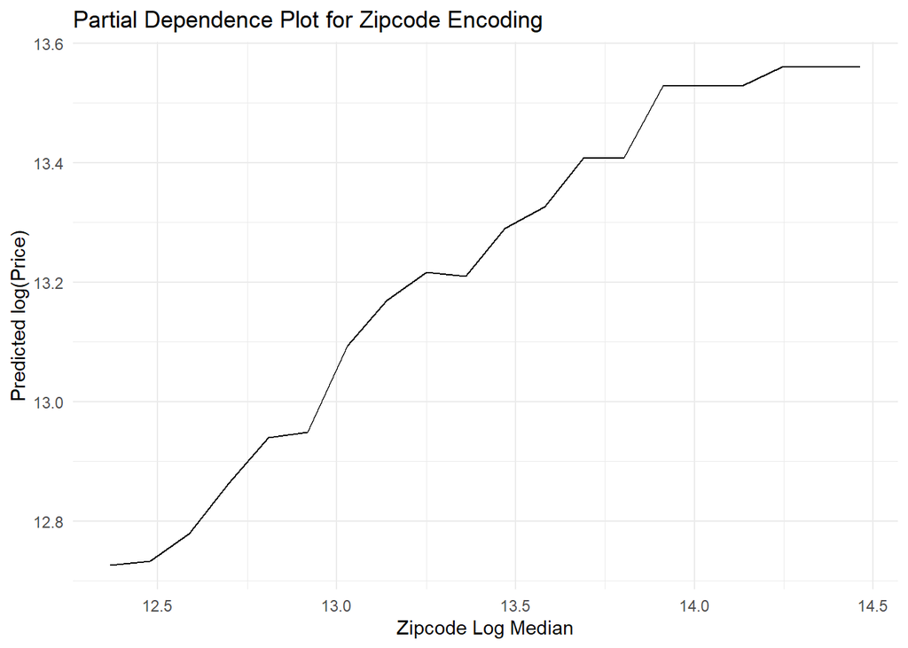

```r
boost_zip_pdp <- partial(
  object = boost_model,
  pred.var = "zipcode_log_median",
  train = x_train,
  grid.resolution = 20,
  n.trees = 4000
)

autoplot(boost_zip_pdp) +
  labs(
    title = "Partial Dependence Plot for Zipcode Encoding",
    x = "Zipcode Log Median",
    y = "Predicted log(Price)"
  ) +
  theme_minimal()
```

# 13 Model Comparison

This table compares the benchmark tree and the three required ensemble methods using the same held-out test set.

```r
comparison_table <- bind_rows(
  tibble(
    Method = "Decision Tree",
    Tuning = paste0("cp = ", round(best_cp, 5)),
    RMSE = tree_test_metrics$RMSE,
    MAE = tree_test_metrics$MAE,
    MSE = tree_test_metrics$MSE,
    R2 = tree_test_metrics$R2
  ),
  tibble(
    Method = "Bagging",
    Tuning = paste0("ntree = ", best_bag_ntree, ", mtry = ", p),
    RMSE = bagging_test_metrics$RMSE,
    MAE = bagging_test_metrics$MAE,
    MSE = bagging_test_metrics$MSE,
    R2 = bagging_test_metrics$R2
  ),
  tibble(
    Method = "Random Forest",
    Tuning = paste0("ntree = ", best_rf_ntree, ", mtry = ", best_mtry),
    RMSE = rf_test_metrics$RMSE,
    MAE = rf_test_metrics$MAE,
    MSE = rf_test_metrics$MSE,
    R2 = rf_test_metrics$R2
  ),
  tibble(
    Method = "Boosting",
    Tuning = paste0(
      "n.trees = ", best_boost_params$best_iter,
      ", depth = ", best_boost_params$interaction.depth,
      ", shrinkage = ", best_boost_params$shrinkage,
      ", n.minobsinnode = ", best_boost_params$n.minobsinnode
    ),
    RMSE = boost_test_metrics$RMSE,
    MAE = boost_test_metrics$MAE,
    MSE = boost_test_metrics$MSE,
    R2 = boost_test_metrics$R2
  )
) %>%
  arrange(RMSE)

kable(
  comparison_table,
  digits = 4,
  caption = "Comparison of Decision Tree, Bagging, Random Forest, and Boosting"
)
```

Comparison of Decision Tree, Bagging, Random Forest, and Boosting

| Method | Tuning | RMSE | MAE | MSE | R2 |
| --- | --- | --- | --- | --- | --- |
| Boosting | n.trees = 4000, depth = 5, shrinkage = 0.01, n.minobsinnode = 5 | 108637.3 | 63186.63 | 11802053177 | 0.8928 |
| Random Forest | ntree = 1000, mtry = 11 | 120440.4 | 65748.20 | 14505886496 | 0.8683 |
| Bagging | ntree = 1000, mtry = 23 | 122107.1 | 66690.59 | 14910152294 | 0.8646 |
| Decision Tree | cp = 0.00011 | 146213.7 | 84044.78 | 21378442908 | 0.8059 |

# 14 Variable Importance

```r
boost_importance <- summary(boost_model, plotit = FALSE)
importance_rf <- importance(rf_model)
importance_bag <- importance(bagging_model)
importance_tree <- pruned_tree$variable.importance

boost_importance_df <- boost_importance %>%
  select(Variable = var, Importance = rel.inf) %>%
  arrange(desc(Importance)) %>%
  slice_head(n = 15)

rf_importance_df <- data.frame(
  Variable = names(importance_rf),
  Importance = as.numeric(importance_rf)
) %>%
  arrange(desc(Importance)) %>%
  slice_head(n = 15)

bag_importance_df <- data.frame(
  Variable = names(importance_bag),
  Importance = as.numeric(importance_bag)
) %>%
  arrange(desc(Importance)) %>%
  slice_head(n = 15)

tree_importance_df <- data.frame(
  Variable = names(importance_tree),
  Importance = as.numeric(importance_tree)
) %>%
  arrange(desc(Importance)) %>%
  slice_head(n = 15)

kable(boost_importance_df, digits = 4, caption = "Top 15 Boosting Importance Values")
kable(rf_importance_df, digits = 4, caption = "Top 15 Random Forest Importance Values")
kable(bag_importance_df, digits = 4, caption = "Top 15 Bagging Importance Values")
kable(tree_importance_df, digits = 4, caption = "Top 15 Decision Tree Importance Values")
```

Top 15 Boosting Importance Values

|  | Variable | Importance |
| --- | --- | --- |
| zipcode_log_median | zipcode_log_median | 39.2642 |
| sqft_living | sqft_living | 24.1063 |
| grade | grade | 17.3330 |
| lat | lat | 6.3128 |
| view | view | 2.6057 |
| long | long | 2.1673 |
| yr_built | yr_built | 1.7293 |
| sqft_living15 | sqft_living15 | 1.1556 |
| sqft_lot | sqft_lot | 0.9843 |
| waterfront | waterfront | 0.9402 |
| condition | condition | 0.8182 |
| sqft_above | sqft_above | 0.7508 |
| sale_time_numeric | sale_time_numeric | 0.4847 |
| bathrooms | bathrooms | 0.3277 |
| sqft_lot15 | sqft_lot15 | 0.3175 |

Top 15 Random Forest Importance Values

| Variable | Importance |
| --- | --- |
| zipcode_log_median | 1524.9958 |
| sqft_living | 980.6041 |
| grade | 781.6954 |
| lat | 473.8618 |
| sqft_above | 184.3145 |
| sqft_living15 | 179.9657 |
| long | 149.6048 |
| yr_built | 77.4635 |
| sqft_lot | 64.7241 |
| bathrooms | 64.5712 |
| view | 63.8457 |
| sqft_lot15 | 54.9588 |
| sale_time_numeric | 40.7602 |
| sqft_basement | 27.5940 |
| waterfront | 26.8790 |

Top 15 Bagging Importance Values

| Variable | Importance |
| --- | --- |
| zipcode_log_median | 2144.1381 |
| sqft_living | 1353.6509 |
| grade | 402.4155 |
| long | 177.0220 |
| lat | 159.4304 |
| sqft_living15 | 84.5087 |
| view | 61.6472 |
| yr_built | 61.3165 |
| sqft_lot | 60.1807 |
| sqft_above | 56.6865 |
| sqft_lot15 | 45.5824 |
| sale_time_numeric | 43.0150 |
| waterfront | 31.1357 |
| sale_day | 26.6054 |
| condition | 23.3843 |

Top 15 Decision Tree Importance Values

| Variable | Importance |
| --- | --- |
| zipcode_log_median | 2217.9457 |
| sqft_living | 1583.1401 |
| lat | 1469.9648 |
| grade | 1209.0842 |
| sqft_living15 | 1048.3523 |
| sqft_above | 1040.5421 |
| bathrooms | 546.8566 |
| sqft_lot15 | 398.5117 |
| sqft_lot | 376.4260 |
| sqft_basement | 214.4085 |
| long | 201.0172 |
| bedrooms | 170.4175 |
| yr_built | 99.4919 |
| view | 73.4005 |
| waterfront | 34.1905 |